# Test1sol

Catastrophist

2022/3/15

1. [mpg dataset] Make a scatterplot of cty vs displ, set the color of the points to blue

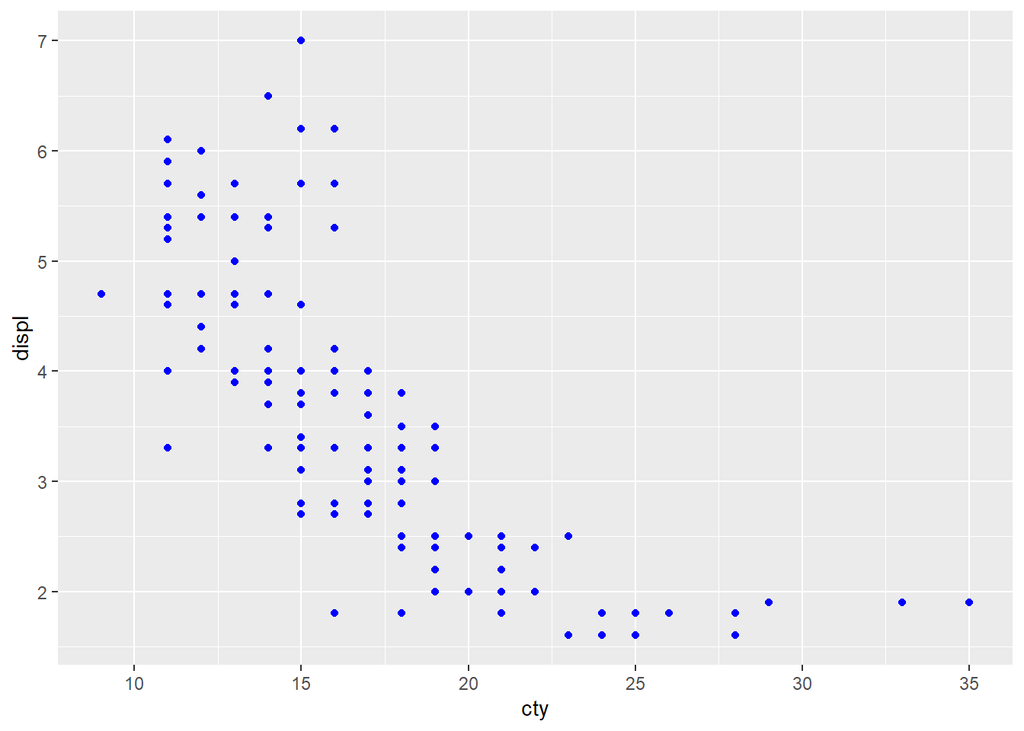

```r
ggplot(data = mpg) +
  geom_point(mapping = aes(x = cty, y = displ),color='blue')
```

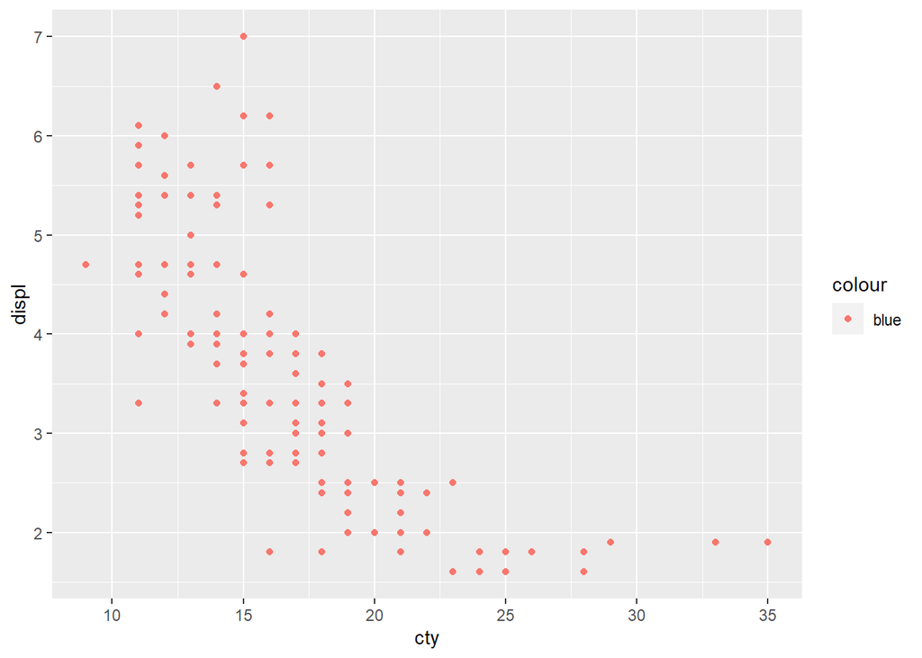

```r
ggplot(data = mpg) +
  geom_point(mapping = aes(x = cty, y = displ,color='blue'))
```

2. Fix the following two graphs

```r
ggplot(data=diamonds)+geom_bar(mapping=aes(x=cut,y=..prop..))
```

[output not shown]

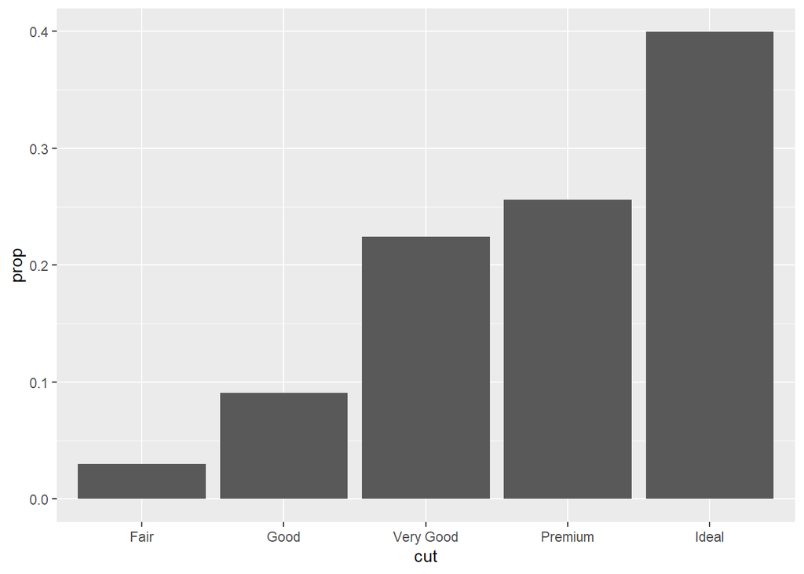

```r
ggplot(data=diamonds)+geom_bar(mapping=aes(x=cut,y=..prop..,group=1))
```

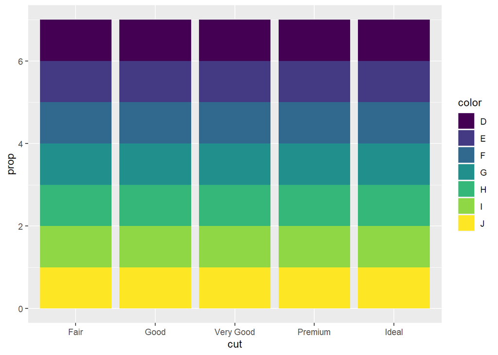

```r
ggplot(data=diamonds)+geom_bar(mapping=aes(x=cut,fill=color,y=..prop..))
```

```r
ggplot(data=diamonds)+geom_bar(mapping=aes(x=cut,fill=color,y=..prop..,group=color))
```

[output not shown]

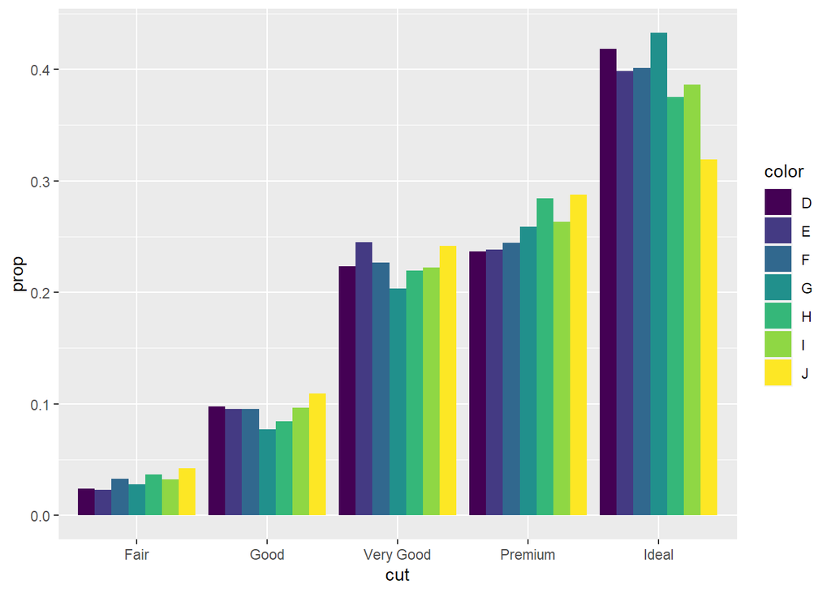

```r
ggplot(data=diamonds)+geom_bar(mapping=aes(x=cut,fill=color,y=..prop..,group=color),position = "dodge")
```

To understand why, let’s first list all the possible inputs:

1.various `group` variable 2.`fill` equal to `color` 3.`position` argument

Then we introduce the function `ggplot_build`, it shows how the plot is structured.

```
## [[1]]
##   y count prop x flipped_aes PANEL group ymin ymax xmin xmax colour   fill size
## 1 1  1610    1 1       FALSE     1     1    0    1 0.55 1.45     NA grey35  0.5
## 2 1  4906    1 2       FALSE     1     2    0    1 1.55 2.45     NA grey35  0.5
## 3 1 12082    1 3       FALSE     1     3    0    1 2.55 3.45     NA grey35  0.5
## 4 1 13791    1 4       FALSE     1     4    0    1 3.55 4.45     NA grey35  0.5
## 5 1 21551    1 5       FALSE     1     5    0    1 4.55 5.45     NA grey35  0.5
##   linetype alpha
## 1        1    NA
## 2        1    NA
## 3        1    NA
## 4        1    NA
## 5        1    NA
```

In this case, group are different, let the calculation of y(prop) is constant.(to be 1)

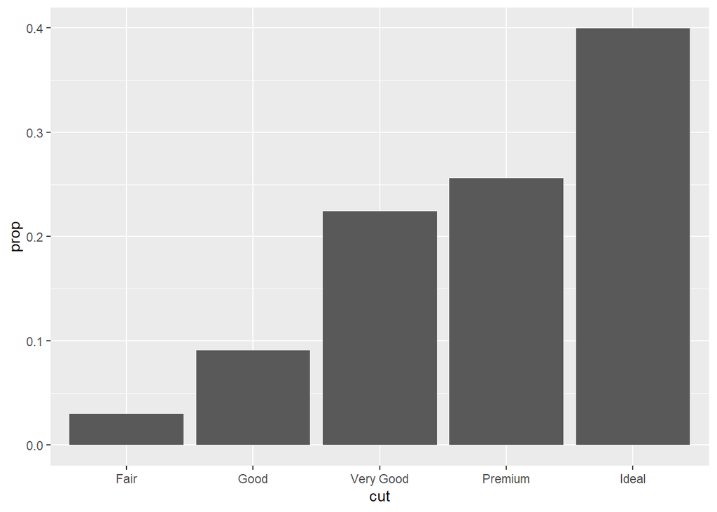

```r
(gplot2 <- ggplot(data=diamonds)+geom_bar(mapping=aes(x=cut,y=..prop..,group=1)))
```

```r
ggplot_build(gplot2)$data
```

```
## [[1]]
##            y count       prop x flipped_aes group PANEL ymin       ymax xmin
## 1 0.02984798  1610 0.02984798 1       FALSE     1     1    0 0.02984798 0.55
## 2 0.09095291  4906 0.09095291 2       FALSE     1     1    0 0.09095291 1.55
## 3 0.22398962 12082 0.22398962 3       FALSE     1     1    0 0.22398962 2.55
## 4 0.25567297 13791 0.25567297 4       FALSE     1     1    0 0.25567297 3.55
## 5 0.39953652 21551 0.39953652 5       FALSE     1     1    0 0.39953652 4.55
##   xmax colour   fill size linetype alpha
## 1 1.45     NA grey35  0.5        1    NA
## 2 2.45     NA grey35  0.5        1    NA
## 3 3.45     NA grey35  0.5        1    NA
## 4 4.45     NA grey35  0.5        1    NA
## 5 5.45     NA grey35  0.5        1    NA
```

In this case, group are all in “1” variable’s group, then we can calculate the proportion of all.

```r
(gplot3 <- ggplot(data=diamonds)+geom_bar(mapping=aes(x=cut,y=..prop..,group=cut)))
```

[output not shown]

```r
ggplot_build(gplot3)$data
```

```
## [[1]]
##   y count prop x flipped_aes group PANEL ymin ymax xmin xmax colour   fill size
## 1 1  1610    1 1       FALSE     1     1    0    1 0.55 1.45     NA grey35  0.5
## 2 1  4906    1 2       FALSE     2     1    0    1 1.55 2.45     NA grey35  0.5
## 3 1 12082    1 3       FALSE     3     1    0    1 2.55 3.45     NA grey35  0.5
## 4 1 13791    1 4       FALSE     4     1    0    1 3.55 4.45     NA grey35  0.5
## 5 1 21551    1 5       FALSE     5     1    0    1 4.55 5.45     NA grey35  0.5
##   linetype alpha
## 1        1    NA
## 2        1    NA
## 3        1    NA
## 4        1    NA
## 5        1    NA
```

In this case, surprisingly we find there’s no difference from caseI. To understand this, we should first know that: When we take `X = cut`, we *ALREADY CUT* the data set into different pieces (5 pieces in `x=cut`).

```r
(gplot4 <- ggplot(data=diamonds)+geom_bar(mapping=aes(x=cut,y=..prop..,group=color)))
```

[output not shown]

```r
ggplot_build(gplot4)$data
```

```
## [[1]]
##             y count       prop x flipped_aes group PANEL       ymin       ymax
## 1  0.21857130   163 0.02405904 1       FALSE     1     1 0.19451226 0.21857130
## 2  0.65548521   662 0.09771218 2       FALSE     1     1 0.55777303 0.65548521
## 3  1.58184074  1513 0.22332103 3       FALSE     1     1 1.35851971 1.58184074
## 4  1.81370149  1603 0.23660517 4       FALSE     1     1 1.57709633 1.81370149
## 5  2.73040126  2834 0.41830258 5       FALSE     1     1 2.31209868 2.73040126
## 6  0.19451226   224 0.02286414 1       FALSE     2     1 0.17164811 0.19451226
## 7  0.55777303   933 0.09523323 2       FALSE     2     1 0.46253980 0.55777303
## 8  1.35851971  2400 0.24497295 3       FALSE     2     1 1.11354675 1.35851971
## 9  1.57709633  2337 0.23854241 4       FALSE     2     1 1.33855392 1.57709633
## 10 2.31209868  3903 0.39838726 5       FALSE     2     1 1.91371142 2.31209868
## 11 0.17164811   312 0.03269755 1       FALSE     3     1 0.13895057 0.17164811
## 12 0.46253980   909 0.09526305 2       FALSE     3     1 0.36727675 0.46253980
## 13 1.11354675  2164 0.22678684 3       FALSE     3     1 0.88675992 1.11354675
```

[output cut: 58 more lines]

We use group parameter `color` in data set rather than united group parameter “1”. In this case, we find there are `35 = 5*7` rows, because we combine two cut methods: `x=cut`(5) and `group=color`(7).

However, when we turn to `fill` column, we find the color doesn’t automatically fitted to different groups or cut, then the group variable is meaningless in reader’s view. Apparently that’s because we didn’t add `color=xxx` in `aes()`, but anyway, we came closer to a **good** graph.

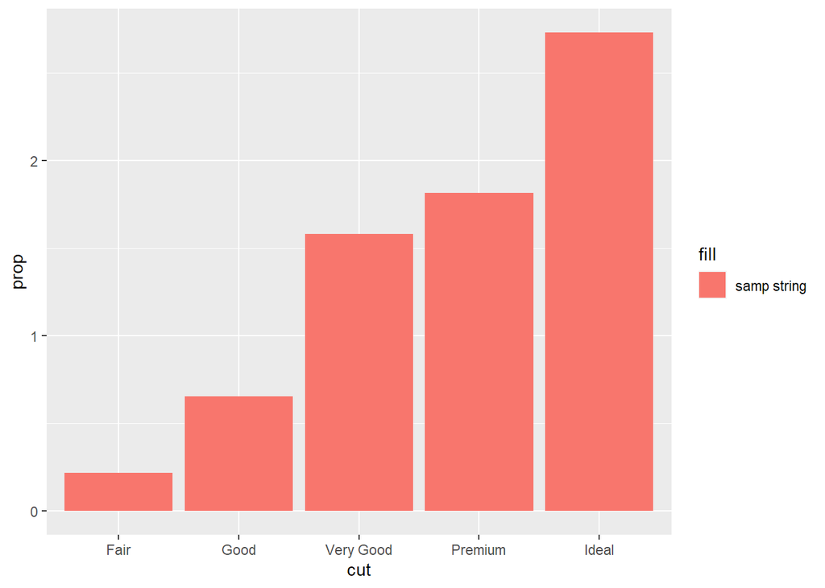

```r
ggplot(data=diamonds)+geom_bar(mapping=aes(x=cut,y=..prop..,group=color,fill='samp string' ))
```

```r
ggplot(data=diamonds)+geom_bar(mapping=aes(x=cut,y=..prop..,group=color,fill=cut))
```

[output not shown]

```r
ggplot(data=diamonds)+geom_bar(mapping=aes(x=cut,y=..prop..,group=color,fill=clarity))
```

[output not shown]

Okay we add `fill` variable now, but there’s no improvement on our circumstances. First we introduced united variable `1` or string`'sample string'`, it changed the whole graph, then we use different variable from `group` like `cut` itself or `clarity` in latter graphs.

That’s because the priority are different.( `Group`, `color`, `alpha`, etc.) Most importantly, `group` has the highest priority among them.

By using `ggplot_build` we could find the numbers of row are always the `X=cut` times `group=color`. Since group variable doesn’t consistent with `color` or `alpha`, the latter are confused and don’t function as the result.

```r
ggplot(data=diamonds)+geom_bar(mapping=aes(x=cut,y=..prop..,group=color,fill=color ))
```

[output not shown]

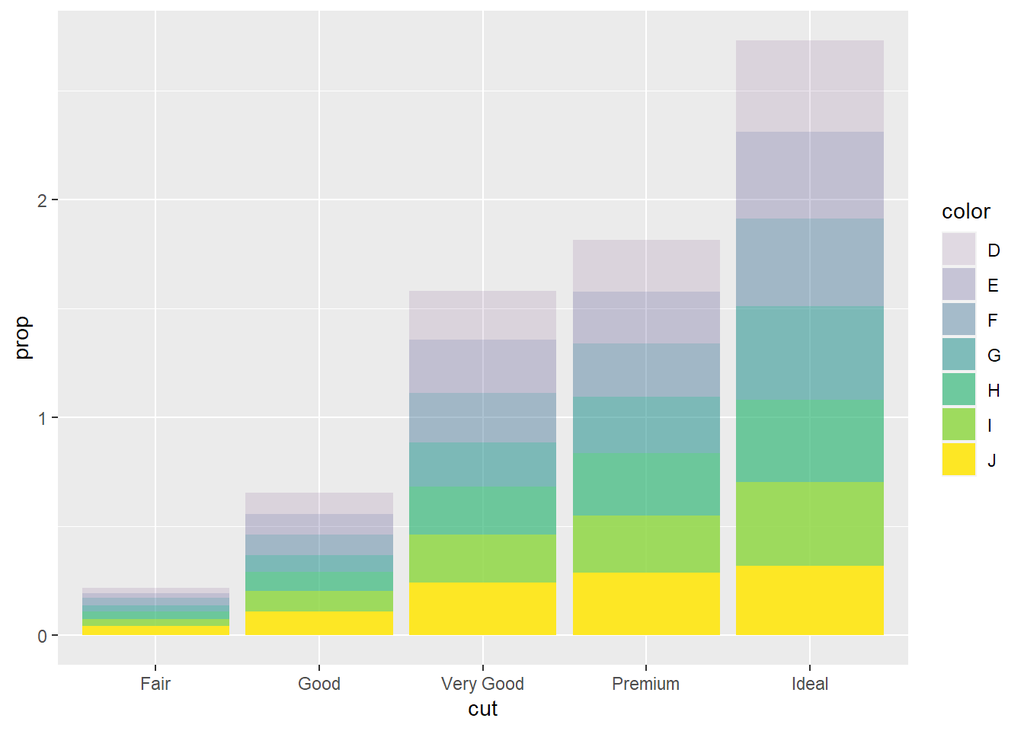

```r
ggplot(data=diamonds)+geom_bar(mapping=aes(x=cut,y=..prop..,group=color,fill=color, alpha=color ))
```

```r
ggplot(data=diamonds)+geom_bar(mapping=aes(x=cut,y=..prop..,group=color,fill=color, alpha=cut ))
```

[output not shown]

Finally by the consistency of group and color, we have a almost nice graph now. The comparation of latter graphs show that when a parameter doesn’t coincide with each other, it simply doesn’t work anymore(without warning).

Then we adjust the Y axis by changing position parameter.

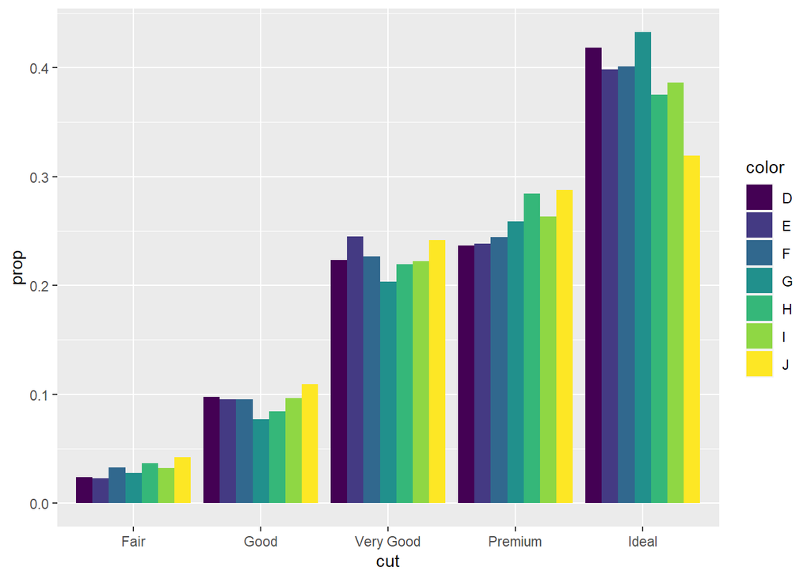

```r
ggplot(data=diamonds)+geom_bar(mapping=aes(x=cut,y=..prop..,group=color,fill=color ),position = 'dodge')
```

This graph show the percentage proportion better.

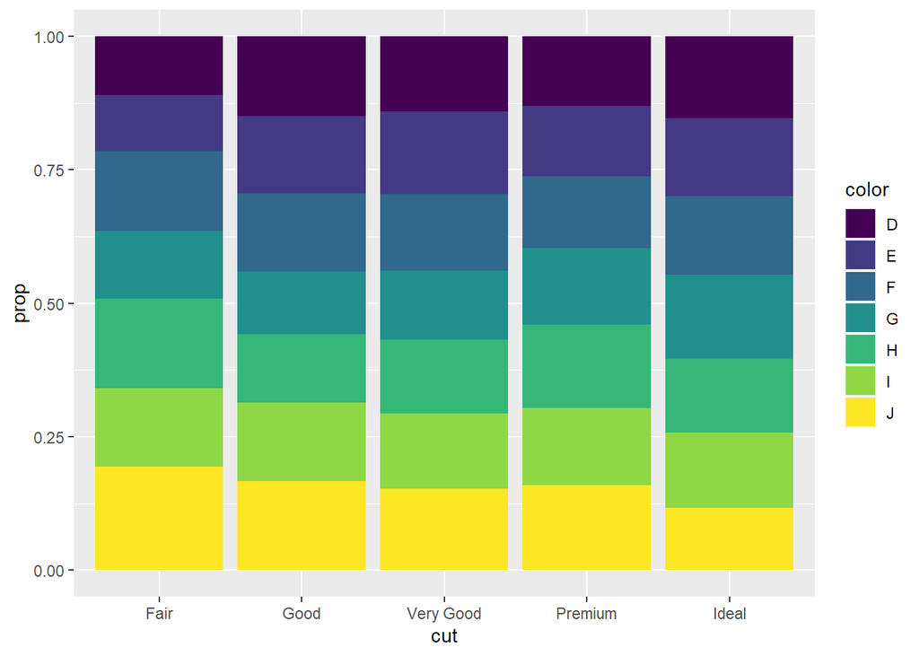

```r
ggplot(data=diamonds)+geom_bar(mapping=aes(x=cut,y=..prop..,group=color,fill=color ),position = 'fill')
```

3.What is the problem with this plot? How could you improve it?

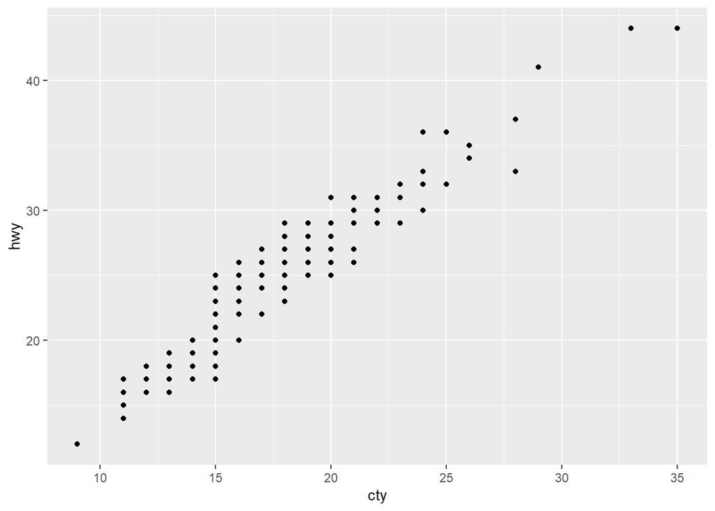

```r
ggplot(data=mpg,mapping=aes(x=cty,y=hwy))+geom_point()
```

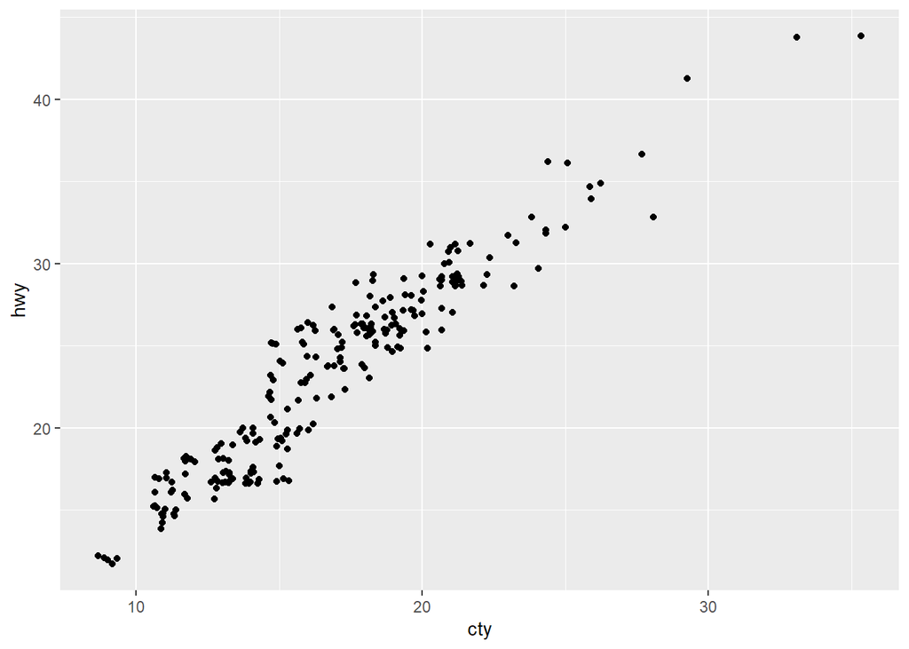

```r
ggplot(data=mpg,mapping=aes(x=cty,y=hwy))+geom_point(position = "jitter")
```

We find strongly positive relations between cty vs. hwy. But the graph is not such intuitive. First, we should make all points visible by adding `position = "jitter"`. Then we can add Title, caption, adjust axis and so on.